# Introduction to DISCO

### Question 2

Power comparison (distance correlation test versus ball covariance test)

Model 1:$Y=X/4+e$

Model 2:$Y=X/4×e$

$I∼N(0_2,I_2),e∼N(0_2,I_2)$, $X$ and $e$ are independent.

### Answer 2

The hypothesis test is:
$$H_0:F_{XY} = F_XF_Y\longleftrightarrow H_1:F_{XY} \neq F_XF_Y$$
Here we give the function to implement the calculation of distance correlation.

```r
library(MASS);library(boot);library(Ball)
dCov <-function(x, y) {
  x <-as.matrix(x);y <-as.matrix(y)
  n <-nrow(x); m <-nrow(y)
  if(n!=m||n<2) stop("Sample sizes must agree")
  if(!(all(is.finite(c(x, y)))))
    stop("Data contains missing or infinite values")
  Akl <-function(x) {
    d <-as.matrix(dist(x))
    m <-rowMeans(d);
    M <-mean(d)
    a <-sweep(d, 1, m);
    b <-sweep(a, 2, m)
    return(b+M)
  }
  A <-Akl(x);
  B <-Akl(y)
  sqrt(mean(A*B))
}

ndCov2 <-function(z, ix, dims) {#dims contains dimensions of x and y
  p <- dims[1]
  q <- dims[2]
  d <- p+q
  x <- z[ , 1:p]#leave x as is
  y <- z[ix,-(1:p)]#permute rows of y
  return(nrow(z)* dCov(x, y)^2)
  }
```

(Sorry for the limited calculation ability of my computer, I set some parameters `m`,`R` to a low amount)

Now we calculate the empirical power of Model 1:$Y=X/4+e$:

```r
n <- c(30,50,80,100,120,150,200)
alpha <- 0.1 #significance level
m <- 200 # Monte Carlo times
powers1 <- data.frame(matrix(0,nrow = 2,ncol = length(n)))
for(i in 1:length(n)){
  p.cor <- numeric(m);p.ball <- numeric(m)
  for(j in 1:m){
    mu = c(0,0); sigma = matrix(c(1,0,0,1),nrow = 2)
    x1 <- mvrnorm(n[i],mu,sigma); e <- mvrnorm(n[i],mu,sigma)
    y1 <- x1/4 + e
    z <- matrix(c(x1,y1),nrow = n[i])
    # permutation: resampling without replacement
    boot.obj <- boot(data = z, statistic = ndCov2, R = 99,
                 sim = "permutation", dims =c(2, 2))
    tb <- c(boot.obj$t0, boot.obj$t)
    p.cor[j] <- mean(tb >= tb[1])
    p.ball[j] <- as.numeric(bcov.test(z[,1:2],z[,3:4],R = 99,seed = j)$p.value)
  }
  powers.cor <- mean(p.cor < alpha)
  powers.ball <- mean(p.ball < alpha)
  powers1[,i] <- c(powers.cor,powers.ball)
}
```

We show the results in a table.

```r
rownames(powers1) <- c("distance correlation test","ball covariance test")
name.str <- c()
for(i in 1:length(n)){
  name.str <- c(name.str,paste("n is",n[i]))
}
colnames(powers1) <- name.str
knitr::kable(powers1)
```

|  | n is 30 | n is 50 | n is 80 | n is 100 | n is 120 | n is 150 | n is 200 |
| --- | --- | --- | --- | --- | --- | --- | --- |
| distance correlation test | 0.375 | 0.560 | 0.755 | 0.835 | 0.895 | 0.960 | 0.990 |
| ball covariance test | 0.260 | 0.335 | 0.520 | 0.540 | 0.675 | 0.825 | 0.905 |

Now we calculate the empirical power of Model 2:$Y=X/4*e$:

```r
powers2 <- data.frame(matrix(0,nrow = 2,ncol = length(n)))
for(i in 1:length(n)){
  p.cor <- numeric(m);p.ball <- numeric(m)
  for(j in 1:m){
    mu = c(0,0); sigma = matrix(c(1,0,0,1),nrow = 2)
    x1 <- mvrnorm(n[i],mu,sigma); e <- mvrnorm(n[i],mu,sigma)
    y1 <- x1/4 * e
    z <- matrix(c(x1,y1),nrow = n[i])
    # permutation: resampling without replacement
    boot.obj <- boot(data = z, statistic = ndCov2, R = 99,
                 sim = "permutation", dims =c(2, 2))
    tb <- c(boot.obj$t0, boot.obj$t)
    p.cor[j] <- mean(tb >= tb[1])
    p.ball[j] <- as.numeric(bcov.test(z[,1:2],z[,3:4],R = 99,seed = j)$p.value)
  }
  powers.cor <- mean(p.cor < alpha)
  powers.ball <- mean(p.ball < alpha)
  powers2[,i] <- c(powers.cor,powers.ball)
}
```

Again, we show the results in a table.

```r
rownames(powers2) <- c("distance correlation test","ball covariance test")
name.str <- c()
for(i in 1:length(n)){
  name.str <- c(name.str,paste("n is",n[i]))
}
colnames(powers2) <- name.str
knitr::kable(powers2)
```

|  | n is 30 | n is 50 | n is 80 | n is 100 | n is 120 | n is 150 | n is 200 |
| --- | --- | --- | --- | --- | --- | --- | --- |
| distance correlation test | 0.575 | 0.73 | 0.83 | 0.92 | 0.96 | 1 | 1 |
| ball covariance test | 0.900 | 1.00 | 1.00 | 1.00 | 1.00 | 1 | 1 |

Now we draw the curve of estimated empirical power to compare two methods.

[figure not shown]

```r
par(mfrow = c(1,2))
plot(n,as.vector(powers1[1,]),xlim = c(10,210),ylim = c(0,1),xlab = "sample size",ylab = "power",main = "power comparision in model 1",type = "l",col = "red")
lines(n,as.vector(powers1[2,]),col = "blue")
legend("bottomright",lty = c(1,1),col=c("red","blue"),legend = c("distance correlation","ball covariance"))
plot(n,as.vector(powers2[1,]),xlim = c(10,210),ylim = c(0,1),xlab = "sample size",ylab = "power",main = "power comparision in model 2",type = "l",col = "red")
lines(n,as.vector(powers2[2,]),col = "blue")
legend("bottomright",lty = c(1,1),col=c("red","blue"),legend = c("distance correlation","ball covariance"))
```

**As we can see, distance correlation have better performance in the linear model 1, while ball covariance test have better performance in the non-linear model 2.**

## HW9:2019-11-29

### Question

Implement a random walk Metropolis sampler for generating the standard Laplace distribution (see Exercise 3.2). For the increment, simulate from a normal distribution. Compare the chains generated when different variances are used for the proposal distribution. Also, compute the acceptance rates of each chain.

### Answer

The standard Laplace distribution is $\frac{1}{2}e^{-|x|}$, so
$$r(x_t,y)=\frac{f(Y)}{f(X_t)}=e^{|x_t|-|y|}$$

```r
r <- function(x,y){
  exp(abs(x)-abs(y))
}
```

Now we write a function to implement the random walk Metropolis sampler to generate the standard Laplace distribution

```r
rw.Metropolis <- function(x0,sigma,N) {
  #x0: the initial point
  #sigma: the standard deviation in the normal distribution
  #N: the length of the chain
  x <- numeric(N)
  x[1] <- x0
  u <- runif(N)
  accept <- 1 #count reject
  for(i in 2:N){
    y <- rnorm(1,x[i-1],sigma)
    if(u[i] <= r(x[i-1],y)){
       x[i] <- y;accept <- accept + 1
    }else{
      x[i] <- x[i-1]
    }
  }
  return(list(x = x,accept = accept))
}
```

Then we generate the chain under different sigma in the proposed distribution

```r
N <- 5000
sigma <- c(0.05,0.5,2,4,8,16)
x0 <- 20
for(i in 1:length(sigma)){
  assign(paste0("rw",i),rw.Metropolis(x0,sigma[i],N))
}
```

We plot the chains under different sigma

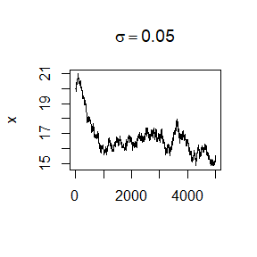

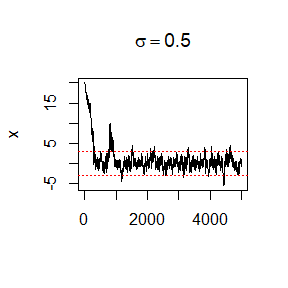

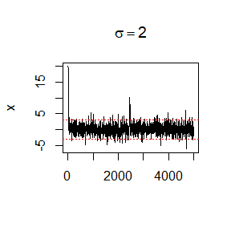

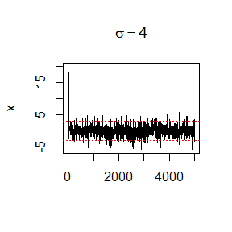

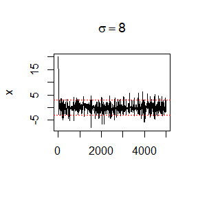

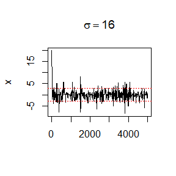

```r
# quantile for laplace distribution(0.025,0.975)
quantile <- c(log(0.05),-log(0.05))
index <- 1:N
for(i in 1:length(sigma)){
  plot(index,get(paste0("rw",i))$x,type = "l",ylab = "x",xlab = "",
       main = bquote(sigma == .(sigma[i])))
  abline(h = quantile,col ="red",lty = 3)
}
```

We can see the first chain with $\sigma = 0.05$ doesn’t converge at 2000 times.

Here we compute the accpetance rate:

```r
a <- matrix(0,nrow = 1,ncol = length(sigma))
rownames(a) <- "accpetance rate"
col_name <- character(length(sigma))
for(i in 1:length(sigma)){
  col_name[i] <- paste0("sigma = ",sigma[i])
  a[1,i] <- get(paste0("rw",i))$accept / N
}
colnames(a) <- col_name
knitr::kable(a)
```

|  | sigma = 0.05 | sigma = 0.5 | sigma = 2 | sigma = 4 | sigma = 8 | sigma = 16 |
| --- | --- | --- | --- | --- | --- | --- |
| accpetance rate | 0.9802 | 0.8268 | 0.5332 | 0.3428 | 0.1926 | 0.1078 |

**As the sigma increases, the accpetance rate goes down, but the convergence speed becomes faster.**

Calculate the quantiles for standard Laplace distribution, and compare with the chain without the first 500 values.

```r
a <- c(0.1,0.2,0.3,0.4,0.45)
# quantile for laplace distribution(0.05,0.1,0.2,0.3,0.4,0.5,0.6,0.7,0.8,0.9,0.95)
q <- c(log(1-2*rev(a)),0,-log(1-2*a))
a1 <- c(rev(0.5-a),0.5,0.5 + a)
rw <- cbind(rw1$x,rw2$x,rw3$x,rw4$x,rw5$x,rw6$x)
mc <- rw[501:N,]
# quantiles of generated chain
Qrw <- apply(mc,2,function(x) quantile(x,a1))
b <- round(cbind(q,Qrw),3)
colnames(b) <- c("quantile",col_name)
knitr::kable(b)
```

|  | quantile | sigma = 0.05 | sigma = 0.5 | sigma = 2 | sigma = 4 | sigma = 8 | sigma = 16 |
| --- | --- | --- | --- | --- | --- | --- | --- |
| 5% | -2.303 | 15.208 | -2.053 | -2.118 | -2.293 | -2.194 | -2.607 |
| 10% | -1.609 | 15.540 | -1.431 | -1.565 | -1.716 | -1.477 | -2.085 |
| 20% | -0.916 | 15.848 | -0.771 | -0.908 | -0.999 | -0.920 | -1.197 |
| 30% | -0.511 | 16.030 | -0.400 | -0.468 | -0.583 | -0.509 | -0.741 |
| 40% | -0.223 | 16.186 | -0.120 | -0.181 | -0.242 | -0.212 | -0.221 |
| 50% | 0.000 | 16.372 | 0.115 | 0.045 | -0.032 | 0.027 | -0.023 |
| 60% | 0.223 | 16.576 | 0.373 | 0.281 | 0.197 | 0.205 | 0.199 |
| 70% | 0.511 | 16.718 | 0.769 | 0.642 | 0.506 | 0.453 | 0.413 |
| 80% | 0.916 | 16.861 | 1.319 | 1.088 | 0.905 | 0.873 | 0.845 |
| 90% | 1.609 | 17.115 | 2.166 | 1.907 | 1.490 | 1.607 | 1.373 |
| 95% | 2.303 | 17.290 | 3.239 | 2.625 | 2.072 | 2.269 | 1.978 |

It seems that set $\sigma = 4$ may be a reasonable choice, let’s check it.

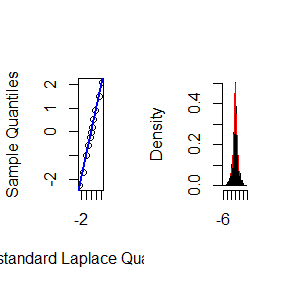

```r
# q: quantiles of Laplace
# Qrw[,4]: quantiles of the chain with sigma is 4
  par(mfrow=c(1,2))
    qqplot(q, Qrw[,4], main="",
        xlab="standard Laplace Quantiles", ylab="Sample Quantiles")
    abline(0,1,col='blue',lwd=2)
    hist(rw4$x[501:N], breaks="scott", main="", xlab="", freq=FALSE)
    lines(q, 0.5*exp(-abs(q)),col = "red")
```

## HW10:2019-12-6

### Question 1

```r
x <- 3.14
# the formula below is not true in computer arithmetic
exp(log(x)) == log(exp(x))
```

```
## [1] FALSE
```

```r
# the all.equal test if two objects are nearly equal
all.equal(exp(log(x)),log(exp(x)))
```

```
## [1] TRUE
```

### Question 2

First, we calculate the root in 11.5

```r
# the integration
integ = function(k,u){
  return((1+u^2/(k))^(-(k+1)/2))
}
#calculate c_k
c_k <- function(k,a){
  sqrt(a^2*k/(k+1-a^2))
}
# the equation in log
equation <- function(k,a){
   (log(k) - log(k-1))/2 +
   (2*lgamma(k/2) - lgamma((k+1)/2)- lgamma((k-1)/2)) +
   log(integrate(integ,0,c_k(k-1,a),k = k-1)$value) -
   log(integrate(integ,0, c_k(k,a),k = k)$value)
}
root.equation <- sapply(c(4:25,100,500,1000),function(k){
                           uniroot(equation,interval = c(1,2),k=k)$root})
```

Now we calculate the result in 11.4

```r
equation_11_4 <- function(k,a){
  pt(c_k(k-1,a),df = k-1) - pt(c_k(k,a),df = k)
}
root.curve <- sapply(c(4:25,100,500,1000),function(k){uniroot(equation_11_4,interval = c(1,2),k=k)$root})
```

Now, let’s compare the two results.

```r
result <- cbind(root.equation,root.curve)
colnames(result) <- c("root in 11.5","root in 11.4")
rownames(result) <- as.character(c(4:25,100,500,1000))
knitr::kable(result)
```

|  | root in 11.5 | root in 11.4 |
| --- | --- | --- |
| 4 | 1.492088 | 1.492103 |
| 5 | 1.533559 | 1.533556 |
| 6 | 1.562747 | 1.562744 |
| 7 | 1.584435 | 1.584430 |
| 8 | 1.601193 | 1.601185 |
| 9 | 1.614533 | 1.614521 |
| 10 | 1.625405 | 1.625390 |
| 11 | 1.634436 | 1.634419 |
| 12 | 1.641997 | 1.642038 |
| 13 | 1.648515 | 1.648554 |
| 14 | 1.654154 | 1.654190 |
| 15 | 1.659080 | 1.659114 |
| 16 | 1.663420 | 1.663452 |
| 17 | 1.667273 | 1.667304 |
| 18 | 1.670716 | 1.670745 |
| 19 | 1.673812 | 1.673840 |
| 20 | 1.676611 | 1.676637 |
| 21 | 1.679153 | 1.679178 |
| 22 | 1.681471 | 1.681496 |
| 23 | 1.683594 | 1.683620 |
| 24 | 1.685546 | 1.685572 |
| 25 | 1.687347 | 1.687373 |
| 100 | 1.720599 | 1.720608 |
| 500 | 1.729745 | 1.729756 |
| 1000 | 1.730897 | 1.730908 |

### Question 3

the initial parameter and observed data

```r
set.seed(125)
n_a. <- 28
n_b. <- 24
n_ab <- 70
n_oo <- 41
p0 <- runif(1,0,1)
q0 <- runif(1,0,1-p0)
```

In the E step, we calculate the expectation of log-likelihood function.

```r
likelihood_e <- function(prob,p0,q0){
  r0 <- 1-p0-q0
  p <- prob[1]; q <- prob[2] ; r <- 1-p-q
  - n_a. * (2*log(p)*(p0^2/(p0^2+2*p0*r0)) + log(2*p*r)*(2*p0*r0/(p0^2+2*p0*r0))) -
    n_b. * (2*log(q)*(q0^2/(q0^2+2*q0*r0)) + log(2*q*r)*(2*q0*r0/(q0^2+2*q0*r0))) -
    n_ab * log(2*p*q) - 2*n_oo * log(r^2)
}
```

In the M step, we use function `optim()` to maximize and renew the parameters.

```r
iter <- 0;E1 <- 0;E2 <- 1
while(iter < 200 && abs(E1-E2)> 1e-6){
  output <- optim(par = c(0.1,0.1),likelihood_e,p0 = p0,q0 = q0)
  E1 <- E2;E2 <- output$value
  p0 <- output$par[1]
  q0 <- output$par[2]
  iter <- iter + 1
}
estimate <- data.frame(p0,q0,iter)
colnames(estimate) <- c("p","q","iteration times")
knitr::kable(estimate)
```

| p | q | iteration times |
| --- | --- | --- |
| 0.2540916 | 0.2417525 | 6 |

Because the observed data is not really reasonable, so the estimate cannot fit the observed data well.

## HW11:2019-12-13

### P204 3,4,5

- **Use both for loops and `lapply()` to fit linear models to the `mtcars` using the formulas stored in this lists:**

```r
formulas <- list(
  mpg ~ disp,
  mpg ~ I(1 / disp),
  mpg ~ disp +wt,
  mpg ~ I(1 / disp) + wt
)
```

Use for loops:

```r
models.loop <- list()
for(i in 1:length(formulas)){
  models.loop <- c(models.loop,list(lm(formulas[[i]],data = mtcars)))
}
```

use lapply:

```r
models <- lapply(formulas,lm,data = mtcars)
models
```

```
## [[1]]
##
## Call:
## FUN(formula = X[[i]], data = ..1)
##
## Coefficients:
## (Intercept)         disp
##    29.59985     -0.04122
##
##
## [[2]]
##
## Call:
## FUN(formula = X[[i]], data = ..1)
##
## Coefficients:
## (Intercept)    I(1/disp)
##       10.75      1557.67
##
##
## [[3]]
##
## Call:
## FUN(formula = X[[i]], data = ..1)
##
## Coefficients:
## (Intercept)         disp           wt
##    34.96055     -0.01772     -3.35083
##
##
## [[4]]
##
## Call:
## FUN(formula = X[[i]], data = ..1)
##
## Coefficients:
## (Intercept)    I(1/disp)           wt
##      19.024     1142.560       -1.798
```

- **Fit the model `mpg ~ disp` to each of the bootstrap replicates of `mtcars` in the list below by using a for loop and `lapply()`. Can you do it without an anonymous function?**

```r
bootstraps <- lapply(1:10, function(i){
  rows <- sample(1:nrow(mtcars), rep =TRUE)
  mtcars[rows, ]
})
```

Use for loop

```r
models2.loop <- list()
for(i in 1:10){
  models2.loop <- c(models2.loop,list(lm(mpg ~ disp,data = bootstraps[[i]])))
}
```

Use `lapply()`

```r
models2 <- lapply(bootstraps,lm,formula = mpg~disp)
models2
```

```
## [[1]]
##
## Call:
## FUN(formula = ..1, data = X[[i]])
##
## Coefficients:
## (Intercept)         disp
##    30.65849     -0.04518
##
##
## [[2]]
##
## Call:
## FUN(formula = ..1, data = X[[i]])
##
## Coefficients:
## (Intercept)         disp
##    30.76113     -0.04258
##
##
## [[3]]
##
## Call:
## FUN(formula = ..1, data = X[[i]])
##
## Coefficients:
## (Intercept)         disp
##    27.87521     -0.03583
##
##
## [[4]]
##
## Call:
## FUN(formula = ..1, data = X[[i]])
##
## Coefficients:
## (Intercept)         disp
##    28.27895     -0.03907
##
##
```

[output cut: 43 more lines]

```
## FUN(formula = ..1, data = X[[i]])
##
## Coefficients:
## (Intercept)         disp
##    28.55734     -0.03557
##
##
## [[10]]
##
## Call:
## FUN(formula = ..1, data = X[[i]])
##
## Coefficients:
## (Intercept)         disp
##    29.24600     -0.04071
```

- **For each model in the previous two exercises, extract R^2 using the function below.**

```r
rsq <- function(mod) summary.lm(mod)$r.squared
# The r.squared from four different models
rsq1 <- matrix(c(unlist(sapply(models.loop,rsq)),unlist(sapply(models,rsq))),
               byrow = TRUE, nrow = 2,dimnames = c(list(c("loop","apply")),
                                                   list(c("mpg ~ disp",
                                                          "mpg ~ I(1 / disp)",
                                                          "mpg ~ disp +wt",
                                                          "mpg ~ I(1 / disp) + wt"))))
knitr::kable(rsq1)
```

|  | mpg ~ disp | mpg ~ I(1 / disp) | mpg ~ disp +wt | mpg ~ I(1 / disp) + wt |
| --- | --- | --- | --- | --- |
| loop | 0.7183433 | 0.8596865 | 0.7809306 | 0.8838038 |
| apply | 0.7183433 | 0.8596865 | 0.7809306 | 0.8838038 |

```r
# The r.squared from bootstrap replicates
rsq2<-matrix(c(round(unlist(sapply(models2.loop,rsq)),3),round(unlist(sapply(models2,rsq)),3)),
               byrow = TRUE, nrow = 2,dimnames = c(list(c("loop","apply")),
                                                   list(1:10)))
knitr::kable(rsq2)
```

|  | 1 | 2 | 3 | 4 | 5 | 6 | 7 | 8 | 9 | 10 |
| --- | --- | --- | --- | --- | --- | --- | --- | --- | --- | --- |
| loop | 0.745 | 0.792 | 0.739 | 0.727 | 0.791 | 0.702 | 0.729 | 0.77 | 0.667 | 0.732 |
| apply | 0.745 | 0.792 | 0.739 | 0.727 | 0.791 | 0.702 | 0.729 | 0.77 | 0.667 | 0.732 |

### P214 3,7

- **The following code simulates the performance of a t-test for non-normal data. Use `sapply()` and an annoymous function to extract the p-value from every trial. Extra challenge: get rid of the anonymous function by using`[[` directly.**

```r
trials <- replicate(
  100,
  t.test(rpois(10,10),rpois(7,10)),
  simplify = FALSE
)
```

```r
round(sapply(1:100,function(i){trials[[i]]$p.value}),3)
```

```
##   [1] 0.689 0.182 0.630 0.357 0.844 0.688 0.326 0.845 0.178 0.221 0.404
##  [12] 0.484 0.789 0.760 0.408 0.879 0.396 0.923 0.029 0.901 0.980 0.830
##  [23] 0.132 0.156 0.957 0.880 0.027 0.883 0.508 0.566 0.474 0.979 0.185
##  [34] 0.077 0.700 0.769 0.701 0.071 0.741 0.548 0.559 0.033 0.195 0.680
##  [45] 0.092 0.986 0.691 0.058 0.755 0.159 0.842 0.758 0.381 0.528 0.257
##  [56] 0.387 0.578 0.055 0.365 0.114 0.992 0.216 0.531 0.526 0.366 0.078
##  [67] 0.636 0.650 0.685 0.085 0.417 0.830 0.004 0.179 0.451 0.698 0.152
##  [78] 0.901 0.597 0.536 0.325 0.857 0.811 0.951 0.173 0.653 0.435 0.635
##  [89] 0.300 0.477 0.358 0.779 0.090 0.815 0.835 0.702 0.862 0.354 0.508
## [100] 0.502
```

Use the`[[` to get rid of anonymous function.

```r
round(sapply(trials,"[[","p.value"),3)
```

```
##   [1] 0.689 0.182 0.630 0.357 0.844 0.688 0.326 0.845 0.178 0.221 0.404
##  [12] 0.484 0.789 0.760 0.408 0.879 0.396 0.923 0.029 0.901 0.980 0.830
##  [23] 0.132 0.156 0.957 0.880 0.027 0.883 0.508 0.566 0.474 0.979 0.185
##  [34] 0.077 0.700 0.769 0.701 0.071 0.741 0.548 0.559 0.033 0.195 0.680
##  [45] 0.092 0.986 0.691 0.058 0.755 0.159 0.842 0.758 0.381 0.528 0.257
##  [56] 0.387 0.578 0.055 0.365 0.114 0.992 0.216 0.531 0.526 0.366 0.078
##  [67] 0.636 0.650 0.685 0.085 0.417 0.830 0.004 0.179 0.451 0.698 0.152
##  [78] 0.901 0.597 0.536 0.325 0.857 0.811 0.951 0.173 0.653 0.435 0.635
##  [89] 0.300 0.477 0.358 0.779 0.090 0.815 0.835 0.702 0.862 0.354 0.508
## [100] 0.502
```

- **Implement `mcsapply()`, a multicore version of `sapply()`. Can you implement `mcvapply`, a parallel version of vapply()? Why or why not?**

Let’s see what `sapply` is:

```r
sapply
```

```
## function (X, FUN, ..., simplify = TRUE, USE.NAMES = TRUE)
## {
##     FUN <- match.fun(FUN)
##     answer <- lapply(X = X, FUN = FUN, ...)
##     if (USE.NAMES && is.character(X) && is.null(names(answer)))
##         names(answer) <- X
##     if (!isFALSE(simplify) && length(answer))
##         simplify2array(answer, higher = (simplify == "array"))
##     else answer
## }
## <bytecode: 0x000000001592fd08>
## <environment: namespace:base>
```

We can see that `sapply` actually simplify the results from `lapply`. We can implement `mcsapply` by replacing some parts of `sapply`. Since windows OS don’t support mc.cores > 1, we use package `parallelsugar`

```r
library(parallelsugar)
mcsapply <- function (X, FUN, ..., mc.cores,simplify = TRUE, USE.NAMES = TRUE) {
  FUN <- match.fun(FUN)
  answer <- mclapply(X = X, FUN = FUN, ...,mc.cores = mc.cores)
  if (USE.NAMES && is.character(X) && is.null(names(answer)))
    names(answer) <- X
  if (!isFALSE(simplify) && length(answer))
    simplify2array(answer, higher = (simplify == "array"))
  else answer
}
```

let’s implement a example:

```r
system.time(sapply(1:1e3, function(i) rnorm(5e5)))
```

```
##  用户  系统  流逝
## 38.78  1.06 40.03
```

```r
system.time(mcsapply(1:1e3, function(i) rnorm(5e5), mc.cores = 4))
```

```
##  用户  系统  流逝
##  7.59  7.19 37.21
```

The using time decreases, but the system need more to time allocate the task to different cores.

**We can’t implement a parallel version of `vapply`, because in the `vapply`, we need to make sure if the return value satisfies the pre-specified type, this process cannot be implemented parallel.**

## HW12:2019-12-20

#### Rewrite a Rcpp function

```r
rw.Metropolis <- function(x0,sigma,N) {
  #x0: the initial point
  #sigma: the standard deviation in the normal distribution
  #N: the length of the chain
  x <- numeric(N)
  x[1] <- x0
  u <- runif(N)
  accept <- 1 #count reject
  for(i in 2:N){
    y <- rnorm(1,x[i-1],sigma)
    if(u[i] < exp(abs(x[i-1])-abs(y))){
       x[i] <- y;accept <- accept + 1
    }else{
      x[i] <- x[i-1]
    }
  }
  return(list(x = x,accept = accept))
}
```

```r
library(Rcpp)
cppFunction('List rw_Metropolis_c(double x0, double sigma, int N) {
  NumericVector x(N);
  as<DoubleVector>(x)[0] = x0;
  NumericVector u(N);
  u = as<DoubleVector>(runif(N));
  List out(2);
  int accept = 1;
  for(int i=1;i<N;i++){
    double y = as<double>(rnorm(1,x[i-1],sigma));
    if(u[i] <= exp(abs(x[i-1])-abs(y))){
        x[i] = y;accept = accept + 1;
    }
    else{
        x[i] = x[i-1];
    }
  }
  out[0] = x;
  out[1] = accept;
  return(out);
}')
```

#### Compare the generated random numbers by the two functions using qqplot

First we have a look at the two chains

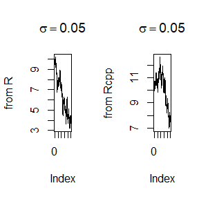

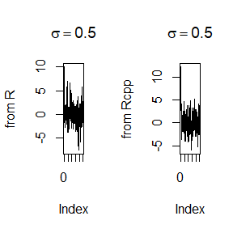

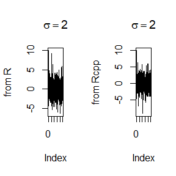

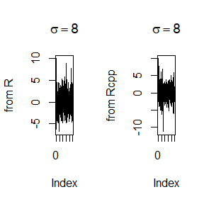

```r
N = 5000; sigma = c(0.05,0.5,2,8);x0 = 10;
for(i in 1:length(sigma)){
  assign(paste0("chain",i),rw.Metropolis(x0,sigma[i],N))
  assign(paste0("chain_c",i),rw_Metropolis_c(x0,sigma[i],N))
}
for(i in 1:length(sigma)){
  par(mfrow = c(1,2))
  plot(get(paste0("chain",i))$x,type = "l", ylab = "from R",
       main = bquote(sigma == .(sigma[i])))
  plot(get(paste0("chain_c",i))[[1]],type = "l", ylab = "from Rcpp",
       main = bquote(sigma == .(sigma[i])))
}
```

Then we compare their acceptance rate:

```r
a <- data.frame(0)
for(i in 1:length(sigma)){
  a <- cbind(a,round(c(get(paste0("chain",i))$accept/N
                       ,get(paste0("chain_c",i))[[2]]/N),2))
  colnames(a)[i+1] <- paste0("sigma = ",sigma[i])
}
a <- a[2:5]
rownames(a) <- c("from R","from Rcpp")
knitr::kable(a)
```

|  | sigma = 0.05 | sigma = 0.5 | sigma = 2 | sigma = 8 |
| --- | --- | --- | --- | --- |
| from R | 0.97 | 0.84 | 0.52 | 0.18 |
| from Rcpp | 0.99 | 0.87 | 0.58 | 0.20 |

Now let’s see the qqplot.

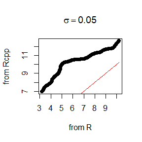

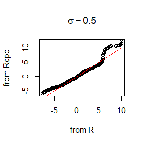

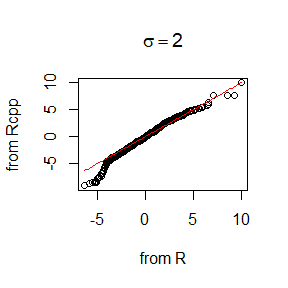

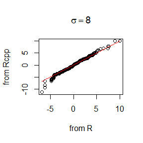

```r
for(i in 1:length(sigma)){
  qqplot(get(paste0("chain",i))$x,
         get(paste0("chain_c",i))[[1]],
         xlab = "from R",ylab = "from Rcpp",
         main = bquote(sigma == .(sigma[i])))
  f <- function(x) x
  curve(f, col = 'red',add = TRUE)
}
```

Frow the figure, we conclude that if the generated chains converge, they have similar quantiles.

we choose the `median` to compare consuming time of two chains

```r
library(microbenchmark)
b <- data.frame(0)
ts1 <- microbenchmark(chain = rw.Metropolis(x0,sigma[1],N),
                     chain_c = rw_Metropolis_c(x0,sigma[1],N))
ts2 <- microbenchmark(chain = rw.Metropolis(x0,sigma[2],N),
                     chain_c = rw_Metropolis_c(x0,sigma[2],N))
ts3 <- microbenchmark(chain = rw.Metropolis(x0,sigma[3],N),
                     chain_c = rw_Metropolis_c(x0,sigma[3],N))
ts4 <- microbenchmark(chain = rw.Metropolis(x0,sigma[4],N),
                     chain_c = rw_Metropolis_c(x0,sigma[4],N))
for(i in 1:length(sigma)){
  b <- cbind(b,summary(get(paste0("ts",i)))$median)
  colnames(b)[i+1] <- paste0("sigma = ",sigma[i])
}
b <- b[2:5]
rownames(b) <- c("from R","from Rcpp")
knitr::kable(b)
```

|  | sigma = 0.05 | sigma = 0.5 | sigma = 2 | sigma = 8 |
| --- | --- | --- | --- | --- |
| from R | 19997.95 | 18136.3 | 13151.40 | 10569.65 |
| from Rcpp | 1003.90 | 767.6 | 745.95 | 685.25 |

**We can conclude that the Rcpp function implement the same work as the R function do, the acceptance rate from two chains is similar, but Rcpp function consume much less time.**